# Presidential Elections: 1.6

Sono Shah

2017-08-22

# Assignments

- Turn in Lab Assignment by tonight.

# Today’s Reading

- Media
- Fake News
- Corrections?

# Who?

- Regular communicators of information designed to reach large audiences
- Newspapers: WSJ, NYT, USA Today
- Television Newscasts
- Cable News: CNN, FOX, MSNBC
- Radio

# Who?

- Most popular source of news today is television newscasts
- Cable News is smaller on average but offers continuous coverage
- radio is a *niche* outlet
- INTERNET: growing

# who III

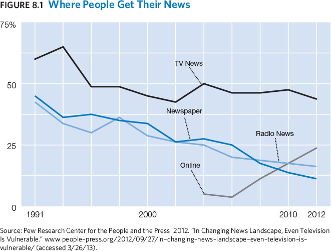

# Oversight

- Not much in the way of oversight, limited to broadcast radio and TV
- **Right to equal time**: stations with FCC are required to provide *equal time* to all candidates for office.
- exceptions include: news interviews and on-the-spot news events, like a presidential press conference

# What Get’s Covered

- novelty
- personality
- conflict
- Skepticism
- Strategy, aka Horse race

# Influence on Citizens

- Media can **inform** voters
- Media can **reinforce** voter’s viewpoints
- Media can manipulate issue salience by **agenda setting**
- Media can **prime** voters to think about issues

# 2016 Election Coverage

- Havard’s Shorenstein Center
- Newspapers: NYT, WSJ, The Washington Post, and USA Today
- TV: ABC World News Tonight, CBS Evening News, CNN’s Situation Room, Fox’s Special Report, and NBC Nightly News

# Coverage

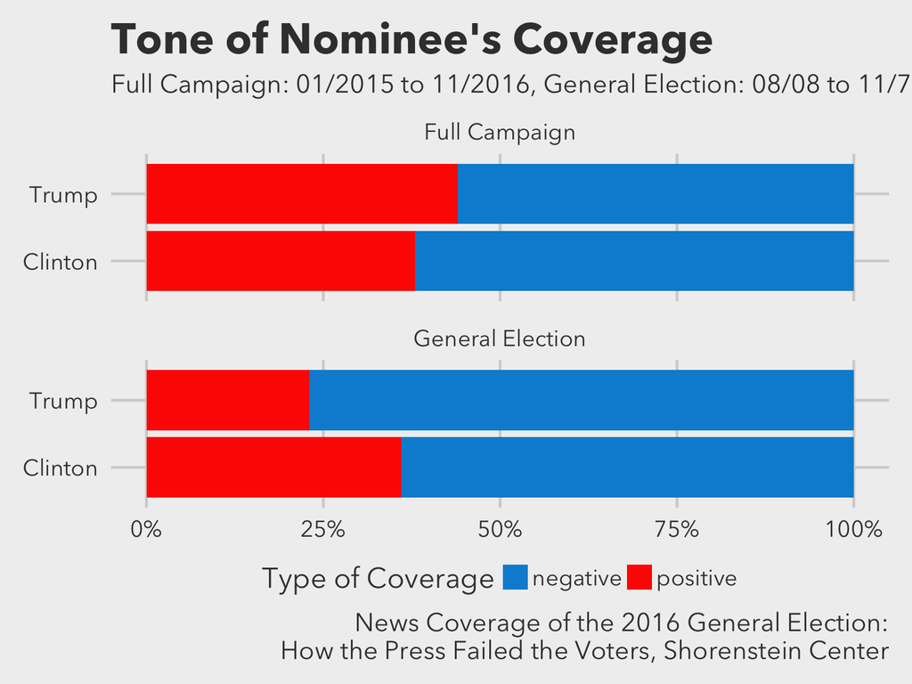

# Sentiment

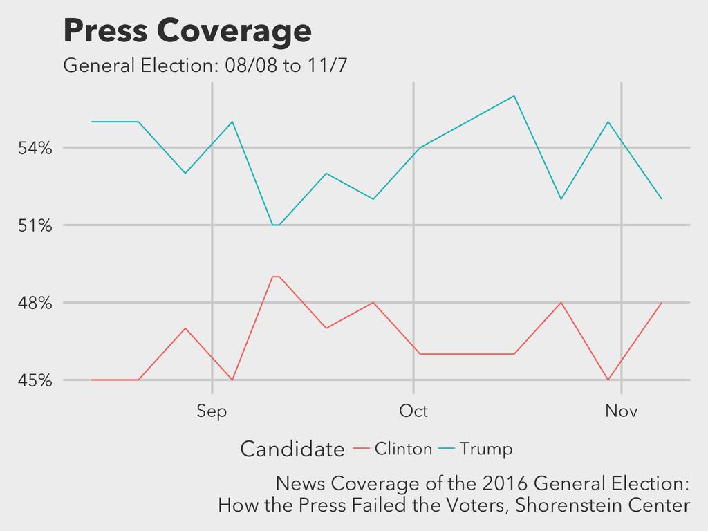

# Topics Covered

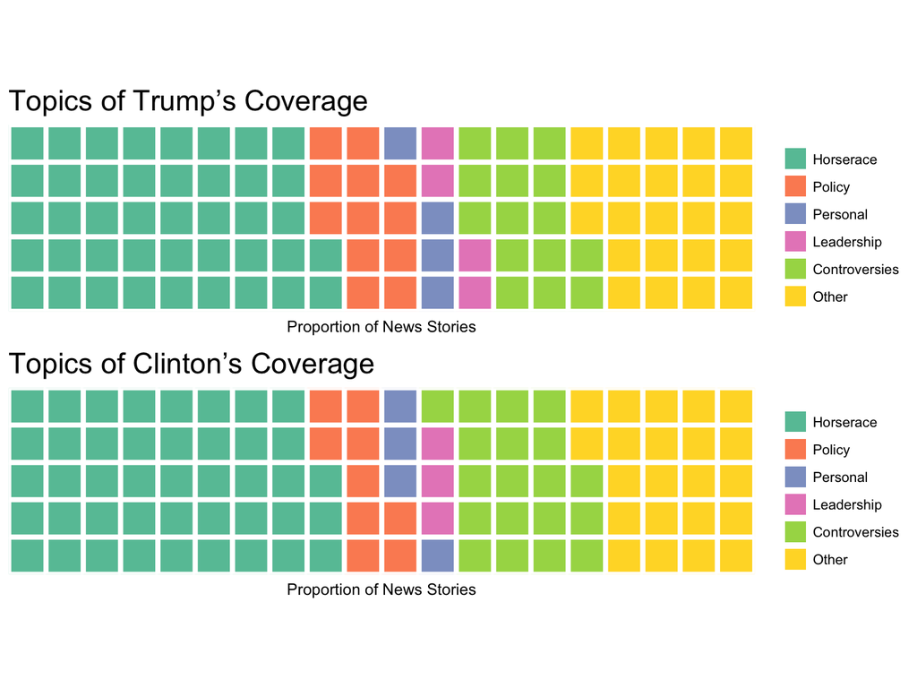

# Coverage II

- Data Face
- 21,981 articles dating back to July 1, 2015
- referencing **Donald Trump** or **Hillary Clinton** in the headline
- NYT, The Washington Post, Chicago Tribune, WSJ, Slate, Politico, Fox News and the Weekly Standard

# Media Attention

[figure not shown]

# Media Sentiment

[figure not shown]

# Free Media

[figure not shown]

# Free Media Value

- TRUMP **$4.96 BILLION**
- CLINTON **$3.24 BILLION**

[Media Quant Report](https://www.mediaquant.net/2016/11/a-media-post-mortem-on-the-2016-presidential-election/)

# Fake News!

http://factitious.augamestudio.com/#/

# Fake News

- Pew Survey on Fake News
- 12/1 to 12/4 2016, 1,002 adults

# Concern across groups

Pew 2016 Report

# Fake News in 2016

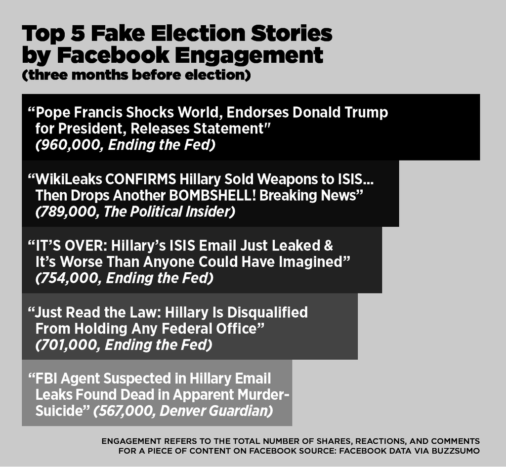

# Fake News in 2016

- We draw on web browsing data, a new 1,200-person post-election online survey, and a database of 156 election-related news stories that were categorized as false by leading fact-checking websites in the three months before the election

Allcott & Gentzkow 2017

# Fake News in 2016

- barriers to entry have dropped dramatically
- social media is built for news dissemination
- declining trust and confidence in mass media

Allcott & Gentzkow 2017

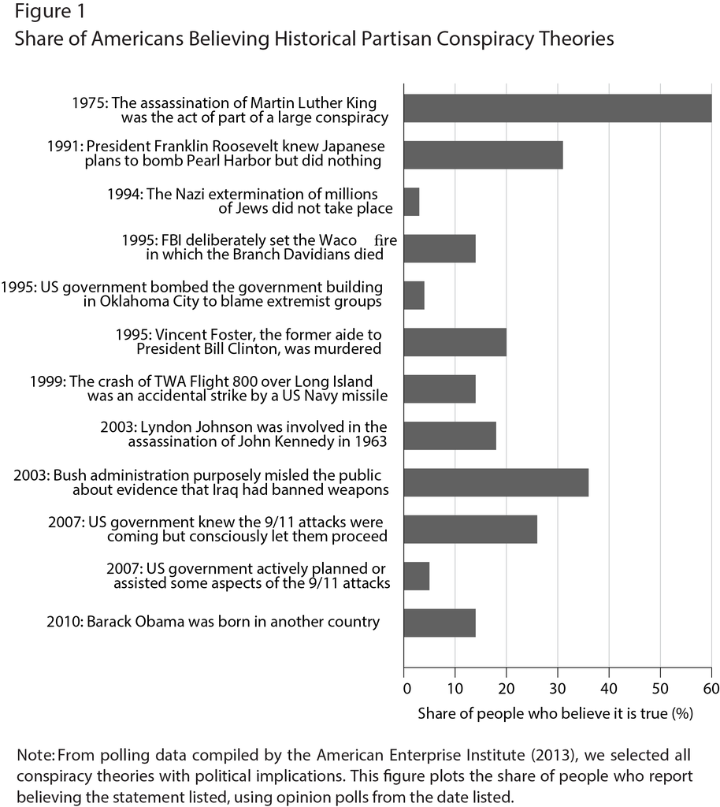

Allcott & Gentzkow 2017

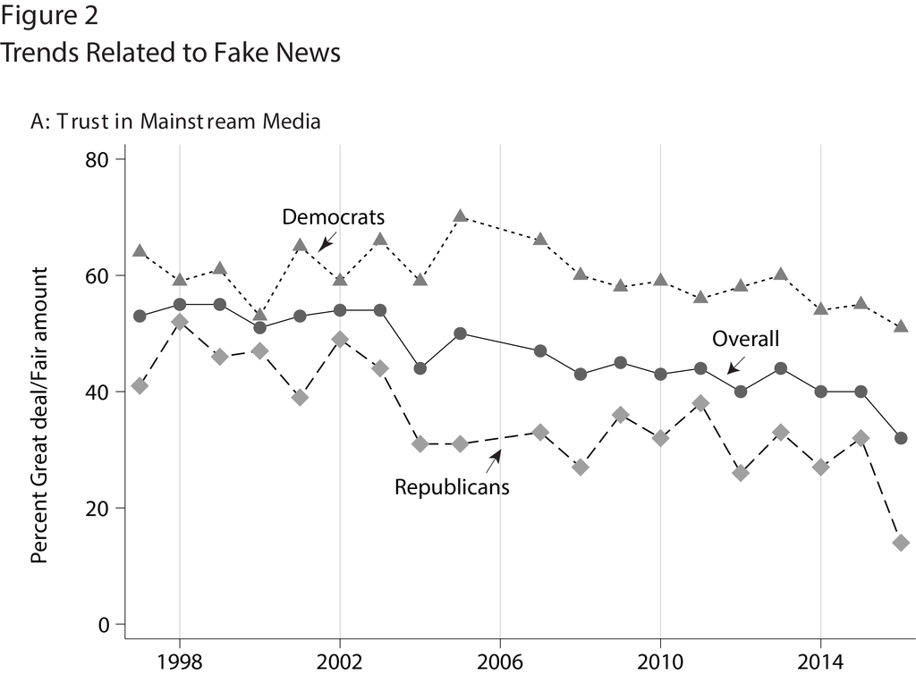

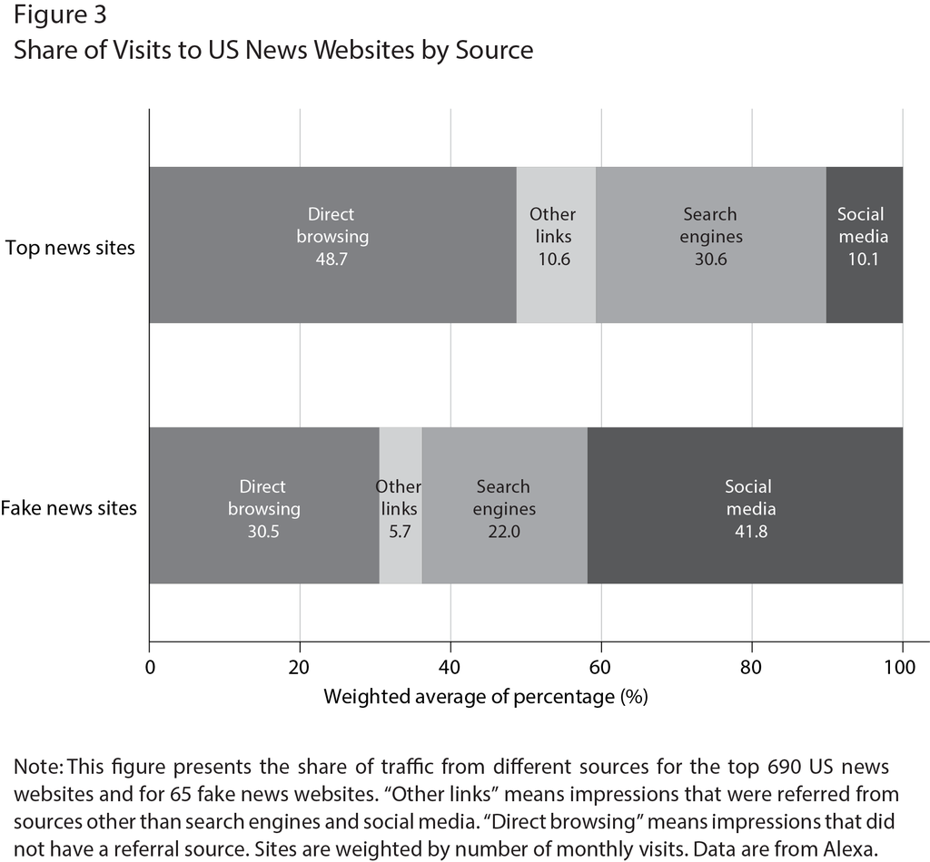

Allcott & Gentzkow 2017

In our fake news database, we record 41 pro-Clinton (or anti-Trump) and 115 pro-Trump (or anti-Clinton) articles, which were shared on Facebook a total of 7.6 million and 30.3 million times, respectively.

Thus, there are about **three times more** fake pro-Trump articles than pro-Clinton articles, and the average pro-Trump article was shared more on Facebook than the average pro-Clinton article.

Allcott & Gentzkow 2017

To be clear, these statistics show that more of the fake news articles on *these three fact- checking sites* are right-leaning. This could be because more of the actual fake news is right-leaning, or because more right-leaning assertions are forwarded to and/or reported by fact-checking sites, or because the conclusions that fact-checking sites draw have a left-leaning bias, or some combination.

Allcott & Gentzkow 2017

# Most Important Source of 2016 Election News

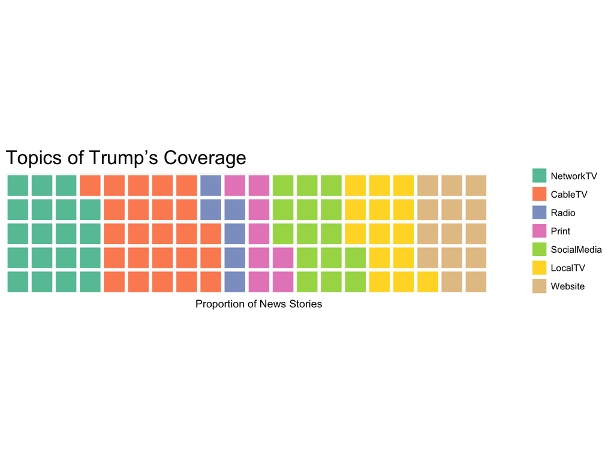

```r
waffle(c(NetworkTV=19, CableTV=24, Radio = 6.2, Print = 8, SocialMedia = 15, LocalTV=14.5, Website =14.8),rows=5, title = "Topics of Trump’s Coverage", xlab = "Proportion of News Stories", size = 1.5)
```

# Findings

- Democrats and Republicans, respectively, are 17.2 and 14.7 percentage points more likely to believe ideologically aligned articles than they are to believe nonaligned articles
- Heavy media consumers are more likely to believe ideologically aligned articles.
- Those with segregated social networks are significantly more likely to believe ideologically aligned articles

Allcott & Gentzkow 2017

# Findings

- “undecided” adults (those who did not make up their minds about whom to vote for until less than three months before the election) are less likely to believe ideologically aligned articles than more decisive voters. This is consistent with undecided voters having less-strong ideologies in the first place.

Allcott & Gentzkow 2017

# Can we fix it?

- Difference between uninformed and being misinformed
- Which one is easer to deal with?
- Is it possible to correct misinformation?

[Nyhan & Reifler 2016](https://link.springer.com/article/10.1007/s11109-010-9112-2)

# Information processing

- Biased search process: seeking out information that supports their preconceptions and avoiding evidence that undercuts their beliefs (Taber & Lodge 2006)
- Backfire effect: people counter argue preference-incongruent information and bolster their preexisting views

[Nyhan & Reifler 2016](https://link.springer.com/article/10.1007/s11109-010-9112-2)

# Research Design

- 4 Experiments
- subjects read mock newspaper articles containing a statement from a political figure that reinforces a widespread misperception.
- participants were randomly assigned to read articles that either included or did not include corrective information immediately.

[Nyhan & Reifler 2016](https://link.springer.com/article/10.1007/s11109-010-9112-2)

# Findings

- Responses to corrections in mock news articles differ significantly according to subjects’ ideological views.
- Corrections fail to reduce misperceptions for the most committed participants.
- They actually strengthen misperceptions among ideological subgroups in several cases.

[Nyhan & Reifler 2016](https://link.springer.com/article/10.1007/s11109-010-9112-2)

# Motivated reasoning

- Direct factual contradictions can actually **strengthen** ideologically grounded factual beliefs.

# Do Facts matter?

- Ideally we want knowing + using correct information
- we can sometimes get: knowing, but ignoring correct information
- believing and using incorrect information

[Hochschild & Einstein 2015](http://onlinelibrary.wiley.com/doi/10.1002/polq.12398/full)

# Using incorrect knowledge

- WMDs in Iraq
- Partisanship

[Hochschild & Einstein 2015](http://onlinelibrary.wiley.com/doi/10.1002/polq.12398/full)

# Using incorrect knowledge

- Child vaccinations
- using misinformation that derives from the *failure* to accept an almost uniform set of elite messages
- cuts across partisanship

[Hochschild & Einstein 2015](http://onlinelibrary.wiley.com/doi/10.1002/polq.12398/full)